# Возможен ли отказ от выборки? Байесовский подход к типологическому исследованию

Г. Мороз (Лаборатория языковой конвергенции)

XV конференция по типологии и грамматике для молодых исследователей  
Санкт-Петербург, 23.11.2018  
Презентация доступна: https://tinyurl.com/ybtpprzk

# Два вида статистики

В статистических исследованиях существует несколько школ, основые (см. (Efron and Hastie 2016)):

1. фриквентистская
2. байесовская

# Разница подходов

В любой задаче мы пытаемся оценить некоторый параметр θ генеральной совокупности.

### Фриквентисткий подход

Фриквентисткий подход исходит из идеи, что есть некоторая генеральная совокупность из которой мы берем выборки и оцениваем параметр θ̂. Таким образом параметр считается фиксированным, а оценка, полученная на основе выборки — результат независимого эксперимента. Результаты разных экспериментов должны быть основаны на разных выборках, а различия, полученные в результате разных экспериментов объясняются флуктуацией выборки.

- параметр θ – фиксирован
- данные варьируются

### Байесовский подход

В байесовском подходе всему, в том числе оцениваемому параметру приписывается вероятностное распределение, которое получается по формуле Байеса из априорного распределения (некоторые изначальные предположения о природе θ) и оценки, полученных из выборки.

- параметр θ – носит вероятностный характер
- данные фиксированы

# Подходы к типологическому исследованию

### Фриквентистский

- Создаем **репрезентативную** выборку языков
- Оцениваем интересующий нас параметр
- При повторном исследовании пересобираем выборку

### Байесовский

- Собираем в априорное распределение наши ожидания, предыдущие работы и т. п.
- Создаем выборку языков
- Обновляем наши ожидания при помощи данных из выборки

# Что потом можно сделать с полученными оценками?

- написать статью
- построить марковские цепи [Manova 2000], [Widmann 2001]

Переходы из одного типа в другой:

| P(VSO → VSO) | P(SVO → VSO) | P(SOV → VSO) |
| --- | --- | --- |
| P(VSO → SVO) | P(SVO → SVO) | P(SOV → SVO) |
| P(VSO → SOV) | P(SVO → SOV) | P(SOV → SOV) |

Произвольные вероятности из [Widmann 2001]:

| 0.90 | 0.02 | 0.01 |
| --- | --- | --- |
| 0.09 | 0.90 | 0.09 |
| 0.01 | 0.08 | 0.90 |

# Markov chains [Widmann 2001]

Type 1: VSO; Type 2: SVO; Type 3: SOV

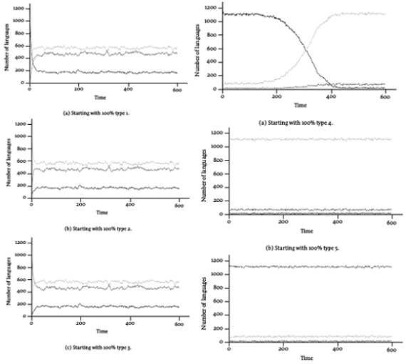

# Недостатки фриквентистского подхода: репрезентативность выборки

- (Bell 1978) “Language Samples”
- (Dryer 1989) “Large Linguistic Areas and Language Sampling”
- (Perkins 1989) “Statistical Techniques for Determining Language Sample Size”
- (Nichols 1992) “Linguistic Diversity in Space and Time”
- (Rietveld and Van Hout 1993) “Statistical Techniques for the Study of Language and Language Behaviour”
- (Rijkhoff and Bakker 1998) “Language sampling”
- (Maslova 2000) “A dynamic approach to the verification of distributional universals”
- (Widmann 2001) “Language Sampling for Typological Studies”
- (Janssen, Bickel, and Zúñiga 2006) “Randomization Tests in Language Typology”
- (Baker 2010) “Language Sampling”

# Недостатки фриквентистского подхода: репрезентативность выборки

- генетические
- контакты
- ? культурные
- типологические
- библиографические
- популяционные

# Недостатки байесовского подхода: априорное распределение

- эта технику ругают за субъективизм
- математическая сложность (лингвистам трудно все, что не пропорция/проценты)

# Мое предложение

- Единицей исследования можно считать языковую семью
- Исследуем все доступные материалы по выборке семей
- Нет выборкам (но если очень нужно их можно делать из всех доступных данных)
- Не обязательно ждать конца исследования, чтобы получить результаты (Байесовское мышление)
- Сравниваем внутригрупповую дисперсию признака с дисперсией по всем группам
  - получаем ответ на вопрос, что редко, что часто
  - получаем “ответ” на вопрос: типологическое vs. ареальное vs. генеалогическое
- Empirical Bayes Estimation
- Missing species problem

# Empirical Bayes Estimation: общее

Empirical Bayes Estimation (Robbins 1985) — это техника, которая позваляет получать априорное распределение на основании большого количества данных.

- Допустим у нас есть несколько языковых семей (с разным количеством языков)
- Для каждого языка мы выясняем параметр θ (например, есть абруптивные звуки?)
- Дальше для каждой языковой семьи мы получаем долю языков с интересующим нас параметром
- Отсекаем семьи с малым количеством языков (я брал семьи с количеством языков больше 5)
- Оцениваем бета распределение (α — количество успехов, β — количество неудач), которое описывает распределение долей в языковых семьях
- Используем полученные параметры бета распределения в качестве априорного распределения для того, чтобы обновить наши данные
- Исследуем выбросы

# Empirical Bayes Estimation: пример 1

Допустим, что мы получили парметры оценки 5 успехов и 15 неудач. Какую оценку получит языковая семья, в которой два языка и оба с абруптивными?

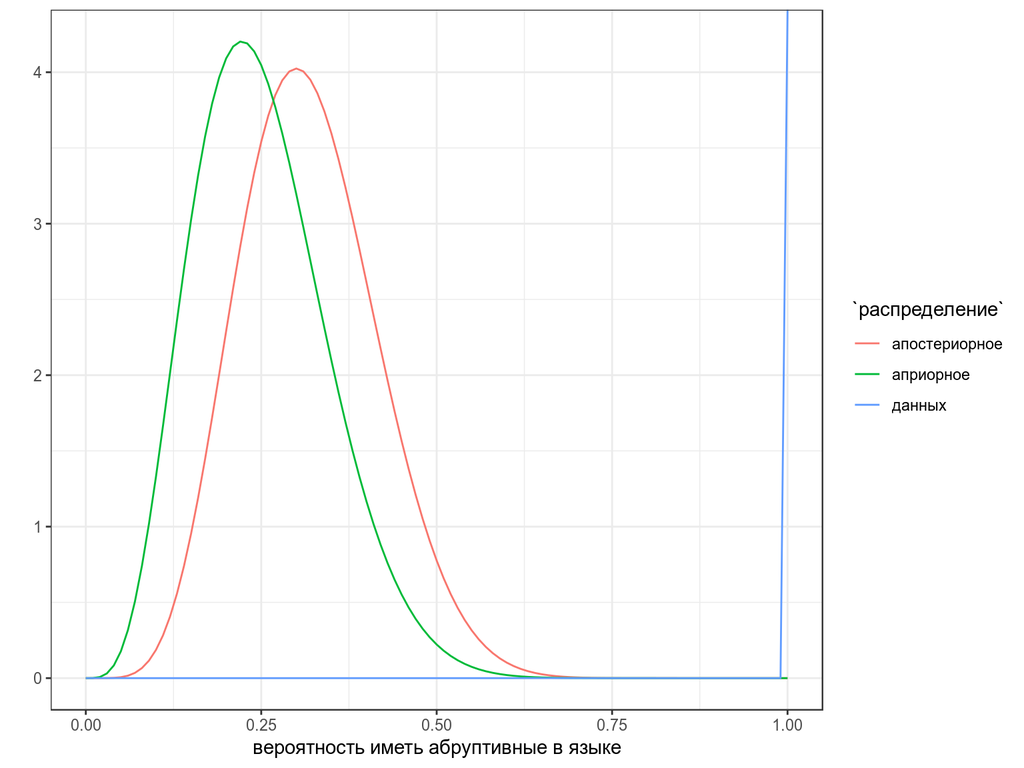

# Empirical Bayes Estimation: пример 2

Допустим, что мы получили парметры оценки 5 успехов и 15 неудач. Какую оценку получит языковая семья, в которой два языка и оба не имеют абруптивных?

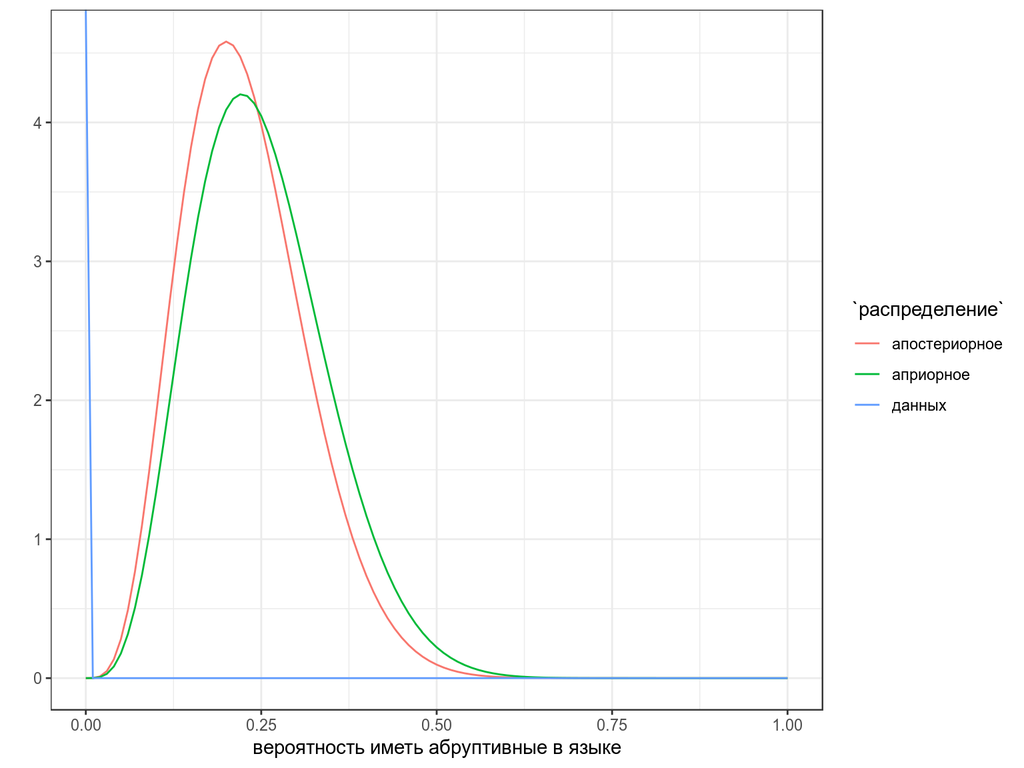

# Empirical Bayes Estimation: пример 3

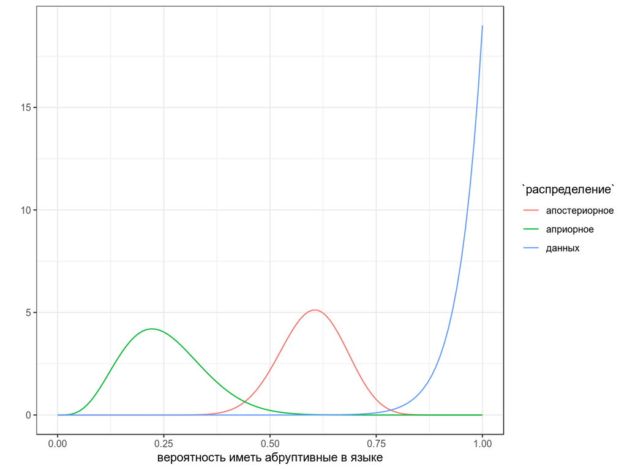

# Empirical Bayes Estimation: исследуем выбросы

- База данных PHOIBLE

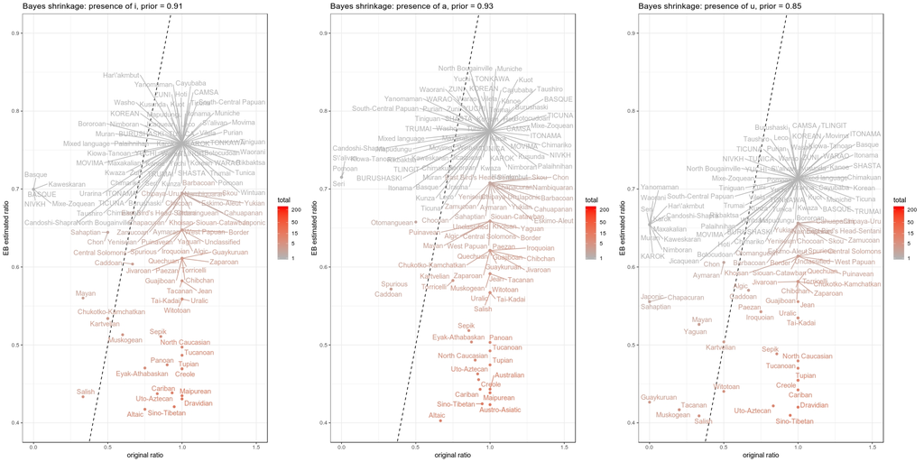

# Спасибо!

Г. Мороз (agricolamz@gmail.com)

Ссылка на презентацию: https://tinyurl.com/ybtpprzk

# Referenses

Baker, D. 2010. “Language Sampling.” In *The Oxford Handbook of Linguistic Typology*, edited by J. J. Song. Oxford University Press.

Bell, A. 1978. “Language Samples.” In *Universals of Human Language, Vol. 4: Syntax*, edited by Joseph Harold Greenberg, Charles Albert Ferguson, and Edith A Moravcsik. Stanford University Press.

Dryer, Matthew S. 1989. “Large Linguistic Areas and Language Sampling.” *Studies in Language. International Journal Sponsored by the Foundation “Foundations of Language”* 13 (2). John Benjamins Publishing Company: 257–92.

Efron, Bradley, and Trevor Hastie. 2016. *Computer Age Statistical Inference*. Vol. 5. Cambridge University Press.

Janssen, Dirk P., Balthasar Bickel, and Fernando Zúñiga. 2006. “Randomization Tests in Language Typology.” *Linguistic Typology*. Walter de Gruyter, 419–40.

Maslova, Elena. 2000. “A Dynamic Approach to the Verification of Distributional Universals.” *Linguistic Typology* 4 (3). Walter de Gruyter, Berlin/New York: 307–33.

Nichols, Johanna. 1992. *Linguistic Diversity in Space and Time*. University of Chicago Press.

Perkins, Revere D. 1989. “Statistical Techniques for Determining Language Sample Size.” *Studies in Language. International Journal Sponsored by the Foundation “Foundations of Language”* 13 (2). John Benjamins Publishing Company: 293–315.

Rietveld, Toni, and Roeland Van Hout. 1993. *Statistical Techniques for the Study of Language and Language Behaviour*. Walter de Gruyter.

Rijkhoff, Jan, and Dik Bakker. 1998. “Language Sampling.” *Linguistic Typology* 2 (3): 263–314.

Robbins, Herbert. 1985. “An Empirical Bayes Approach to Statistics.” In *Herbert Robbins Selected Papers*, 41–47. Springer.

Widmann, Thomas Martin. 2001. “Language Sampling for Typological Studies.” Master’s thesis, University of Aarhus.